# Visualização de Dados com o ggoplot2

Cristiano de Carvalho Santos - Departamento de Estatística da UFMG

## Introdução

O R possui vários sistemas para fazer gráficos, mas o ggplot2 é um dos mais elegantes e versáteis.

- ggplot2 implementa a gramática de gráficos , um sistema coerente para descrever e construir gráficos.
- Com o ggplot2, você pode fazer mais rápido aprendendo um sistema e aplicando-o em muitos lugares.

### Pré -requisitos

Este capítulo se concentra no ggplot2, um dos principais membros do tidyverse. Para acessar os conjuntos de dados, páginas de ajuda e funções que usaremos neste capítulo, carregue o tidyverse executando este código:

```r
library(tidyverse)
```

Se precisarmos ser explícitos sobre a origem de uma função (ou conjunto de dados), usaremos a forma especial **package::function()**.

- Por exemplo, **ggplot2::ggplot()** informa explicitamente que estamos usando a **ggplot()** função do pacote **ggplot2**.

## Primeiros passos

Vamos usar nosso primeiro gráfico para responder a uma pergunta:

- Carros com motores grandes usam mais combustível do que carros com motores pequenos?
- Qual é a relação entre o tamanho do motor e a eficiência de combustível? É positivo? Negativo? Linear? Não linear?

### O banco de dados mpg

Você pode testar sua resposta com o mpg quadro de dados encontrado em `ggplot2` (também conhecido como `ggplot2::mpg`). Um data frame é uma coleção retangular de variáveis (nas colunas) e observações (nas linhas). O mpg contém observações coletadas pela Agência de Proteção Ambiental dos EUA em 38 modelos de carros.

```r
mpg
```

```
## # A tibble: 234 x 11
##    manufacturer model      displ  year   cyl trans drv     cty   hwy fl    class
##    <chr>        <chr>      <dbl> <int> <int> <chr> <chr> <int> <int> <chr> <chr>
##  1 audi         a4           1.8  1999     4 auto~ f        18    29 p     comp~
##  2 audi         a4           1.8  1999     4 manu~ f        21    29 p     comp~
##  3 audi         a4           2    2008     4 manu~ f        20    31 p     comp~
##  4 audi         a4           2    2008     4 auto~ f        21    30 p     comp~
##  5 audi         a4           2.8  1999     6 auto~ f        16    26 p     comp~
##  6 audi         a4           2.8  1999     6 manu~ f        18    26 p     comp~
##  7 audi         a4           3.1  2008     6 auto~ f        18    27 p     comp~
##  8 audi         a4 quattro   1.8  1999     4 manu~ 4        18    26 p     comp~
##  9 audi         a4 quattro   1.8  1999     4 auto~ 4        16    25 p     comp~
## 10 audi         a4 quattro   2    2008     4 manu~ 4        20    28 p     comp~
## # ... with 224 more rows
```

Entre as variáveis mpg estão:

- `displ`, tamanho do motor de um carro, em litros.
- `hwy`, a eficiência de combustível de um carro na estrada, em milhas por galão (mpg).

### Criando um ggplot

Para plotar mpg, execute este código para colocar `displ` no eixo x e `hwy` no eixo y:

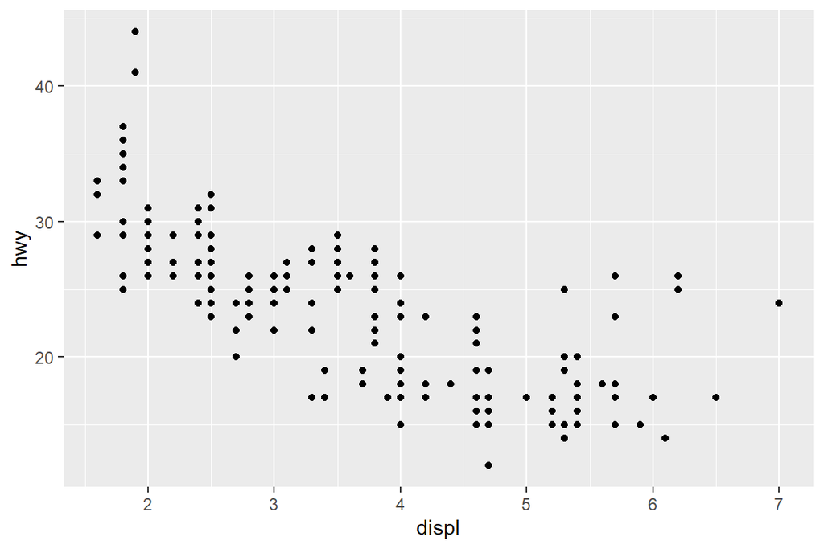

```r
ggplot(data = mpg) +
  geom_point(mapping = aes(x = displ, y = hwy))
```

O gráfico mostra uma relação negativa entre tamanho do motor (`displ`) e eficiência de combustível (`hwy`).

- Em outras palavras, carros com motores grandes usam mais combustível.

Com `ggplot2`, você inicia um gráfico com a função `ggplot()`.

- `ggplot()` cria um sistema de coordenadas ao qual você pode adicionar camadas.
- O primeiro argumento de `ggplot()` é o conjunto de dados a ser usado no gráfico.
- Então `ggplot(data = mpg)` cria um gráfico vazio.

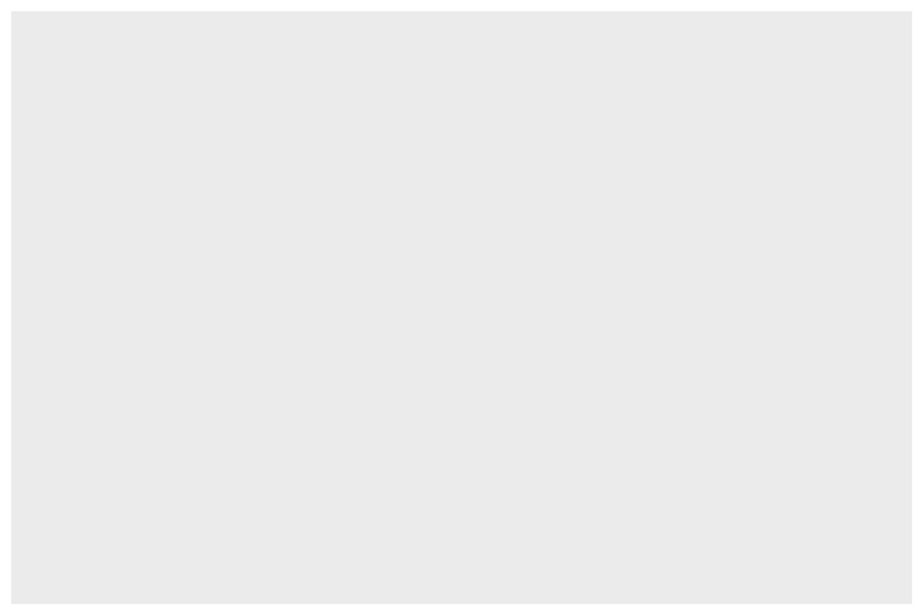

```r
ggplot()
```

Você completa seu gráfico adicionando uma ou mais camadas ao `ggplot()`.

- A função `geom_point()` adiciona uma camada de pontos ao seu gráfico, o que cria um gráfico de dispersão.
- O `ggplot2` vem com muitas funções geom que adicionam um tipo diferente de camada a um gráfico.

Cada função geom em `ggplot2` recebe um argumento `mapping`.

- Isso define como as variáveis em seu conjunto de dados são mapeadas para propriedades visuais.
- O argumento `mapping` é sempre emparelhado com `aes()`, e os argumentos `x` e `y` especificam quais variáveis mapear para os eixos x e y.
- O ggplot2 procura as variáveis mapeadas no argumento `data`, neste caso, `mpg`.

### Um modelo gráfico

Vamos transformar este código em um modelo reutilizável para fazer gráficos com ggplot2. Para fazer um gráfico, substitua as seções entre colchetes no código abaixo por um conjunto de dados, uma função geom ou uma coleção de mapeamentos.

```
ggplot(data = <DATA>) +
 <GEOM_FUNCTION>(mapping = aes(<MAPPINGS>))
```

## Mapeamentos estéticos

`"O maior valor de uma imagem é quando ela nos obriga a perceber o que nunca esperávamos ver." — John Tukey`

> No gráfico abaixo, um grupo de pontos (destacado em vermelho) parece estar fora da tendência linear. Esses carros têm uma quilometragem maior do que você poderia esperar. Como você pode explicar esses carros?

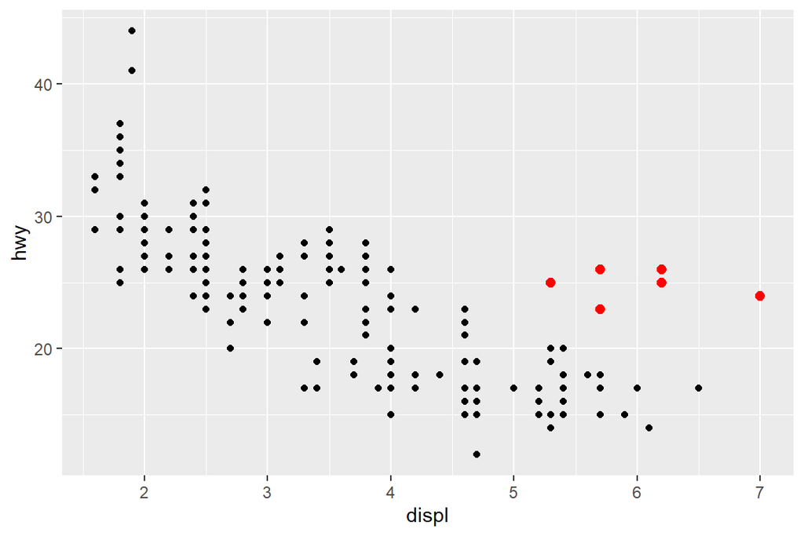

- Vamos supor que os carros são híbridos. Se os pontos periféricos são híbridos, eles devem ser classificados como carros compactos ou, talvez, carros subcompactos.
- A variável `class` do conjunto de dados mpg classifica os carros em grupos como compacto, médio e SUV.

Você pode adicionar uma terceira variável, como class, a um gráfico de dispersão bidimensional mapeando-a para uma estética.

- Uma estética é uma propriedade visual dos objetos em seu plot.
- A estética inclui coisas como o tamanho, a forma ou a cor dos seus pontos.
- Você pode exibir um ponto (como o abaixo) de diferentes maneiras alterando os valores de suas propriedades estéticas.

Aqui alteramos os níveis de tamanho, forma e cor de um ponto para torná-lo pequeno, triangular ou azul:

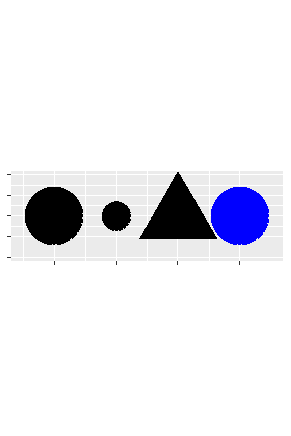

Você pode transmitir informações sobre seus dados mapeando a estética em seu gráfico para as variáveis em seu conjunto de dados.

- Por exemplo, você pode mapear as cores de seus pontos para a variável *class* para revelar a classe de cada carro.

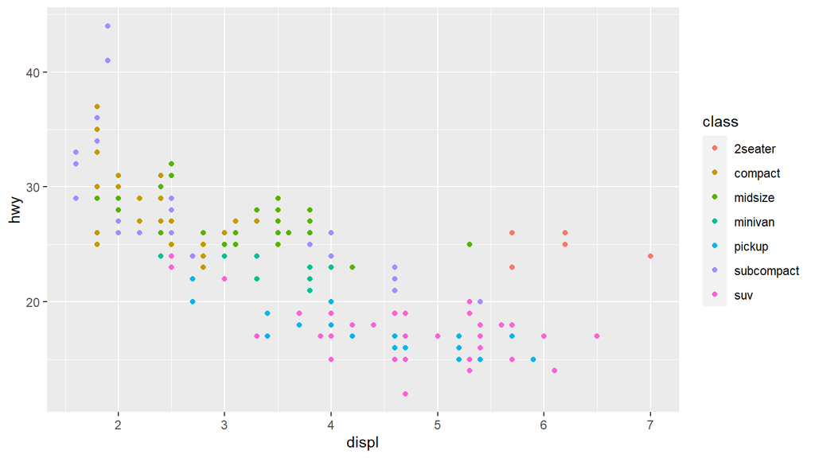

```r
ggplot(data = mpg) +
  geom_point(mapping = aes(x = displ, y = hwy, color = class))
```

Para mapear uma estética para uma variável, associe o nome da estética ao nome da variável dentro de **aes()**.

- O ggplot2 atribuirá automaticamente um nível único da estética (aqui uma cor única) para cada valor único da variável, um processo conhecido como dimensionamento.
- O ggplot2 também adicionará uma legenda que explica quais níveis correspondem a quais valores.

`As cores revelam que muitos dos pontos inusitados são carros de dois lugares. Esses carros não parecem híbridos e são, na verdade, carros esportivos! Os carros esportivos têm motores grandes, como SUVs e picapes, mas corpos pequenos, como carros médios e compactos, o que melhora seu consumo de combustível.`

No exemplo acima, mapeamos *class* para a estética de cor, mas poderíamos ter mapeado *class* para a estética de tamanho da mesma maneira. Nesse caso, o tamanho exato de cada ponto revelaria sua afiliação de classe.

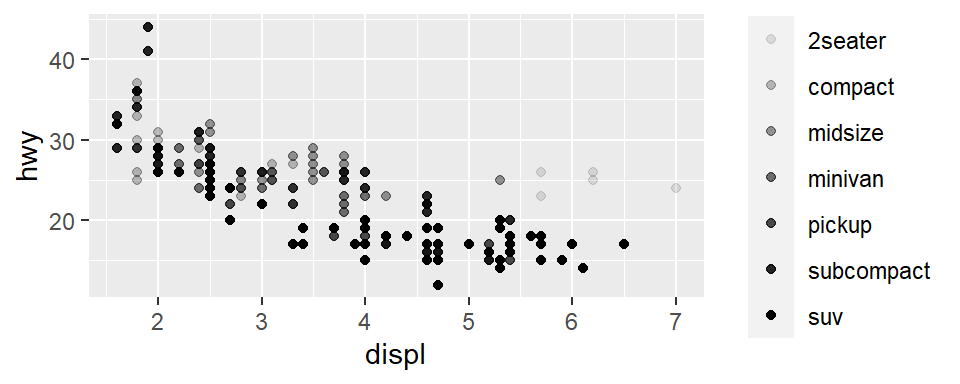

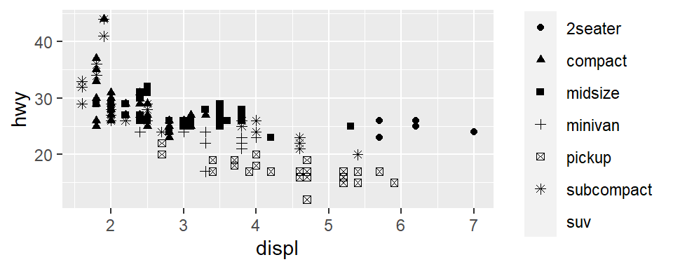

```r
# Left
ggplot(data = mpg) +
  geom_point(mapping = aes(x = displ, y = hwy, alpha = class))

# Right
ggplot(data = mpg) +
  geom_point(mapping = aes(x = displ, y = hwy, shape = class))
```

**O que aconteceu com os SUVs?** ggplot2 usará apenas seis formas por vez. Por padrão, grupos adicionais não serão plotados quando você usar a estética de forma.

Para cada estética, aes() associa o nome da estética a uma variável a ser exibida.

- A função aes() reúne cada um dos mapeamentos estéticos usados por uma camada e os passa para o argumento de mapeamento da camada.
- A sintaxe destaca uma visão útil sobre x e y: as localizações x e y de um ponto são estéticas, propriedades visuais que você pode mapear para variáveis para exibir informações sobre os dados.

Depois de mapear uma estética, o ggplot2 cuida do resto.

- Seleciona uma escala razoável para usar com a estética e constrói uma legenda que explica o mapeamento entre níveis e valores.
- Para estética x e y, o ggplot2 não cria uma legenda, mas cria uma linha de eixo com marcas de escala e um rótulo.

Você também pode definir as propriedades estéticas do seu geom manualmente.

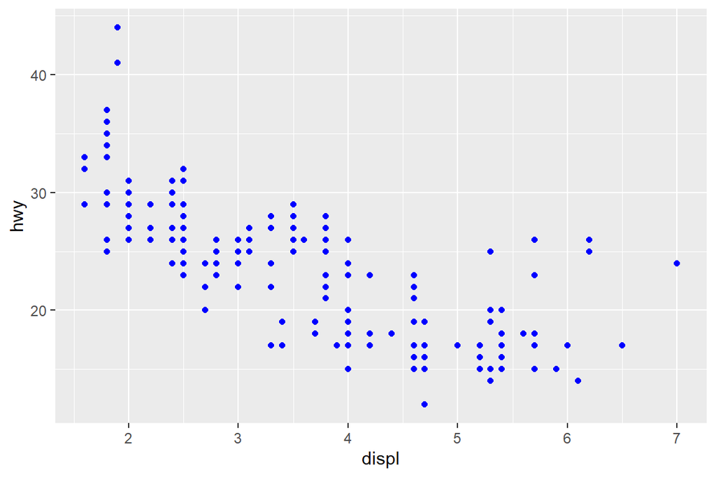

```r
ggplot(data = mpg) +
  geom_point(mapping = aes(x = displ, y = hwy), color = "blue")
```

Aqui, a cor não transmite informações sobre uma variável, mas apenas altera a aparência do gráfico.

- Para definir uma estética manualmente, defina a estética pelo nome como um argumento da sua função geom; ou seja, ele vai para fora do *aes()*.

Você precisará escolher um nível que faça sentido para essa estética:

- O nome de uma cor como uma cadeia de caracteres.
- O tamanho de um ponto em mm.
- A forma de um ponto como um número.

`R tem 25 formas embutidas que são identificadas por números. Existem algumas duplicatas aparentes: por exemplo, 0, 15 e 22 são todos quadrados. A diferença vem da interação da estética cor e fill. As formas ocas (0--14) têm uma borda determinada por cor; as formas sólidas (15--20) são preenchidas com cor; as formas preenchidas (21--24) têm uma borda de cor e são preenchidas com fill`.

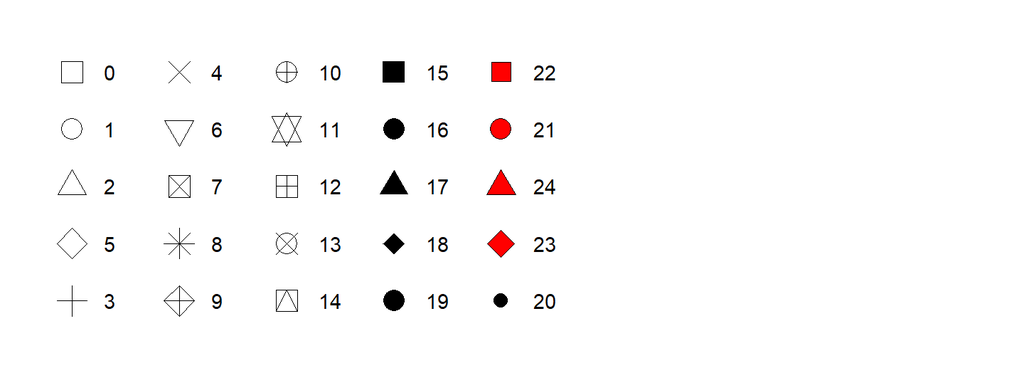

## Problemas comuns

À medida que você começa a executar o código R, é provável que tenha problemas.

- Um problema comum ao criar gráficos ggplot2 é colocar o + no lugar errado: ele tem que vir no final da linha, não no início. Em outras palavras, certifique-se de não ter escrito acidentalmente um código como este:

```r
ggplot(data = mpg)
+ geom_point(mapping = aes(x = displ, y = hwy))
```

## Facetas

Uma maneira de adicionar variáveis adicionais é com a estética. Outra maneira, particularmente útil para variáveis categóricas, é dividir seu gráfico em facetas, subplots em que cada uma exibe um subconjunto dos dados.

Para facetar seu gráfico por uma única variável, use **facet_wrap()**.

- O primeiro argumento de **facet_wrap()** deve ser uma fórmula, com a qual você cria ~ seguido por um nome de variável (aqui “fórmula” é o nome de uma estrutura de dados em R, não um sinônimo de “equação”).
- A variável para a qual você passa **facet_wrap()** deve ser discreta.

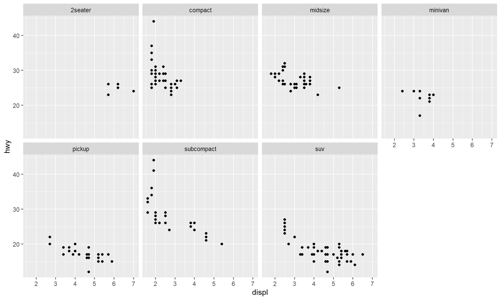

```r
ggplot(data = mpg) +
  geom_point(mapping = aes(x = displ, y = hwy)) +
  facet_wrap(~ class, nrow = 2)
```

Para transformar seu gráfico na combinação de duas variáveis, adicione **facet_grid()** à sua chamada de gráfico.

- O primeiro argumento de **facet_grid()** também é uma fórmula. Desta vez, a fórmula deve conter dois nomes de variáveis separados por um ~.

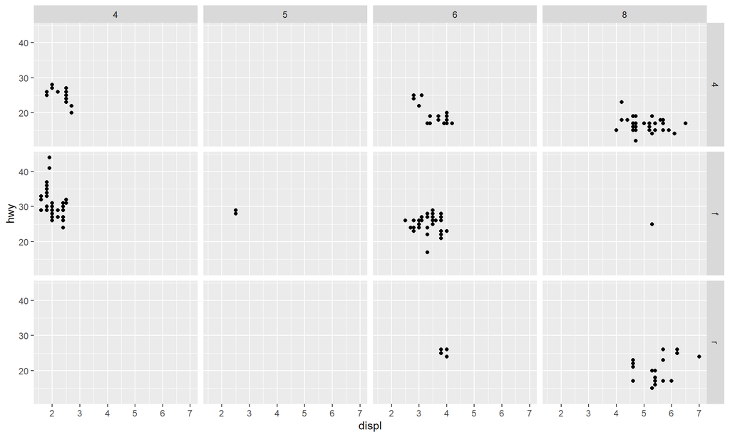

```r
ggplot(data = mpg) +
  geom_point(mapping = aes(x = displ, y = hwy)) +
  facet_grid(drv ~ cyl)
```

Se você preferir não usar facetas na dimensão de linhas ou colunas, use a `.` em vez de um nome de variável, por exemplo **+ facet_grid(. ~ cyl)**.

## Objetos geométricos

Como essas duas tramas são semelhantes?

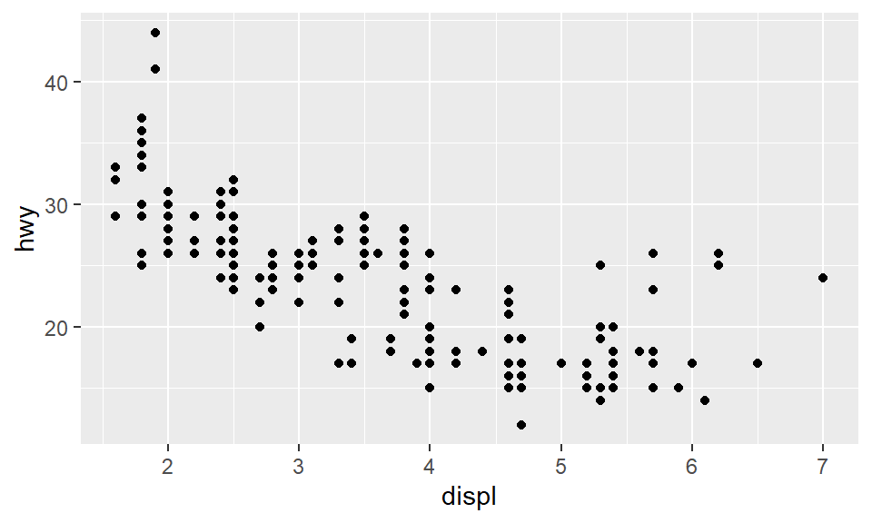

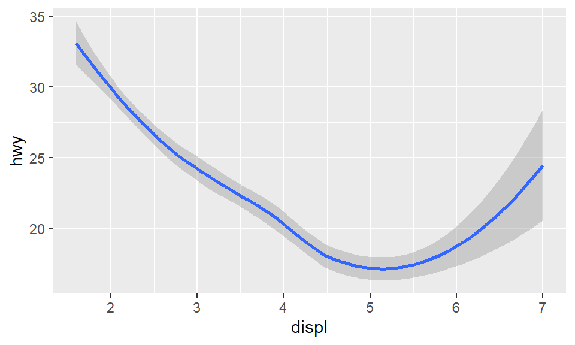

Ambos os gráficos contêm a mesma variável x, a mesma variável y e ambos descrevem os mesmos dados.

- Mas os plots não são idênticos.
- Cada gráfico usa um objeto visual diferente para representar os dados.
- Na sintaxe do ggplot2, dizemos que eles usam geoms diferentes .
  - Um geom é o objeto geométrico que um gráfico usa para representar dados.

Para alterar o geom em seu gráfico, altere a função geom que você adiciona a *ggplot()*.

- Por exemplo, para fazer os gráficos acima, você pode usar este código:

```r
# left
ggplot(data = mpg) +
  geom_point(mapping = aes(x = displ, y = hwy))

# right
ggplot(data = mpg) +
  geom_smooth(mapping = aes(x = displ, y = hwy))
```

- Cada função *geom* no *ggplot2* recebe um argumento *mapping*.
- No entanto, nem toda estética funciona com todas as geometrias.
  - Você pode definir a forma de um ponto, mas não pode definir a “forma” de uma linha. Por outro lado, você pode definir o tipo de linha de uma linha.
- *geom_smooth()* desenhará uma linha diferente, com um tipo de linha diferente, para cada valor exclusivo da variável que você mapear para o tipo de linha.

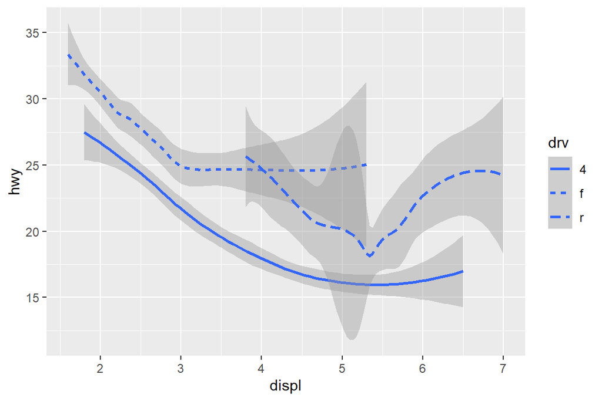

```r
ggplot(data = mpg) +
  geom_smooth(mapping = aes(x = displ, y = hwy, linetype = drv))
```

Aqui *geom_smooth()* separa os carros em três linhas com base em seu valor **drv**, que descreve o trem de força de um carro.

- Uma linha descreve todos os pontos com um valor 4, uma linha descreve todos os pontos com um valor f e uma linha descreve todos os pontos com um valor r.
- Aqui, 4 significa tração nas quatro rodas, f tração dianteira e r tração traseira.

Se isso soa estranho, podemos deixar mais claro sobrepondo as linhas em cima dos dados brutos e depois colorindo tudo de acordo com drv.

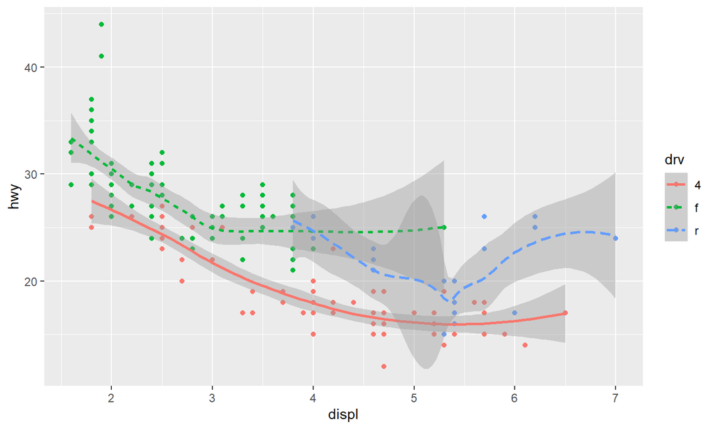

Observe que este gráfico contém duas geometrias no mesmo gráfico!

- O ggplot2 fornece mais de 40 geoms e os pacotes de extensão fornecem ainda mais (consulte https://exts.ggplot2.tidyverse.org/gallery/ para uma amostra).
- A melhor maneira de obter uma visão geral abrangente é a folha de dicas do ggplot2, que você pode encontrar em http://rstudio.com/resources/cheatsheets.
- Para saber mais sobre qualquer geom único, use a ajuda: ?geom_smooth.

Muitos geoms, como *geom_smooth()*, usam um único objeto geométrico para exibir várias linhas de dados.

- Para essas geometrias, você pode definir a estética *group* para uma variável categórica para desenhar vários objetos.
- *ggplot2* desenhará um objeto separado para cada valor exclusivo da variável de agrupamento.
- Na prática, o *ggplot2* agrupará automaticamente os dados para esses geoms sempre que você mapear uma estética para uma variável discreta.
- É conveniente contar com esse recurso porque a estética do grupo por si só não adiciona uma legenda ou características distintivas aos geoms.

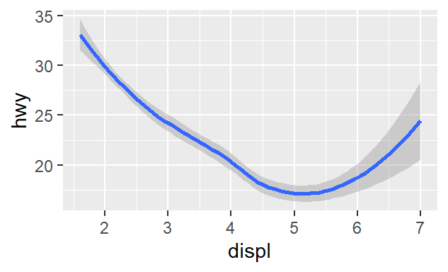

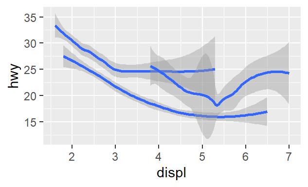

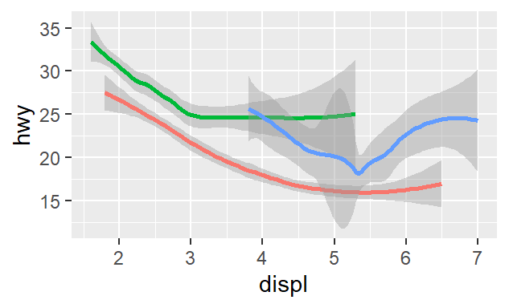

```r
ggplot(data = mpg) +
  geom_smooth(mapping = aes(x = displ, y = hwy))

ggplot(data = mpg) +
  geom_smooth(mapping = aes(x = displ, y = hwy, group = drv))

ggplot(data = mpg) +
  geom_smooth(
    mapping = aes(x = displ, y = hwy, color = drv),
    show.legend = FALSE
  )
```

Para exibir vários geoms no mesmo gráfico, adicione várias funções *geom* a *ggplot()*:

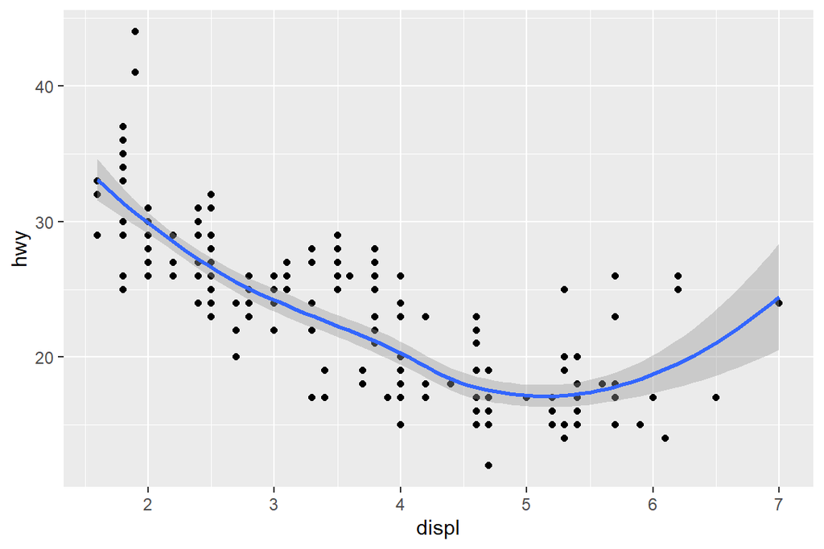

```r
ggplot(data = mpg) +
  geom_point(mapping = aes(x = displ, y = hwy)) +
  geom_smooth(mapping = aes(x = displ, y = hwy))
```

Isso, no entanto, introduz alguma duplicação em nosso código.

- Você pode evitar esse tipo de repetição passando um conjunto de mapeamentos para *ggplot()*.
- O *ggplot2* tratará esses mapeamentos como mapeamentos globais que se aplicam a cada geom no gráfico.

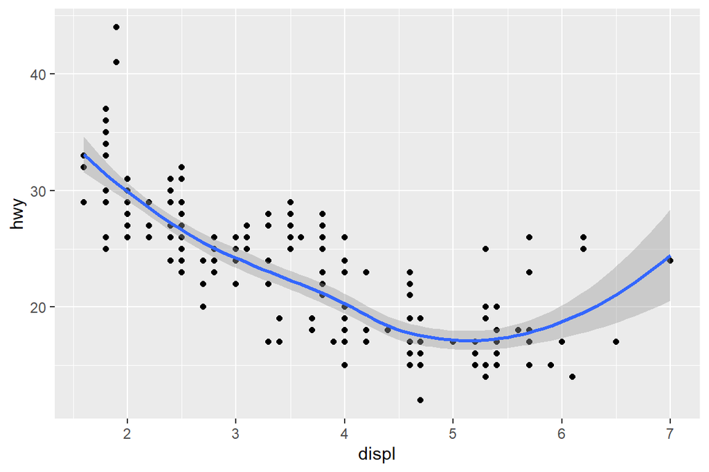

```r
ggplot(data = mpg, mapping = aes(x = displ, y = hwy)) +
  geom_point() +
  geom_smooth()
```

Se você colocar mapeamentos em uma função *geom*, o *ggplot2* os tratará como mapeamentos locais para a camada.

- Ele usará esses mapeamentos para estender ou substituir os mapeamentos globais apenas para essa camada.
- Isso torna possível exibir diferentes estéticas em diferentes camadas.

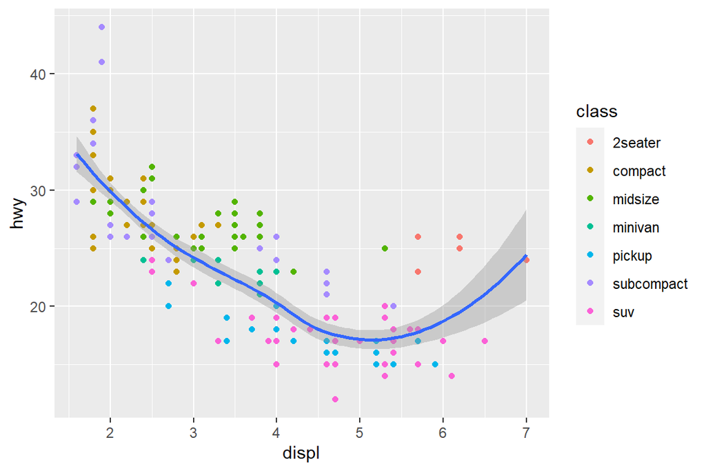

```r
ggplot(data = mpg, mapping = aes(x = displ, y = hwy)) +
  geom_point(mapping = aes(color = class)) +
  geom_smooth()
```

Você pode usar a mesma ideia para especificar diferentes *data* para cada camada.

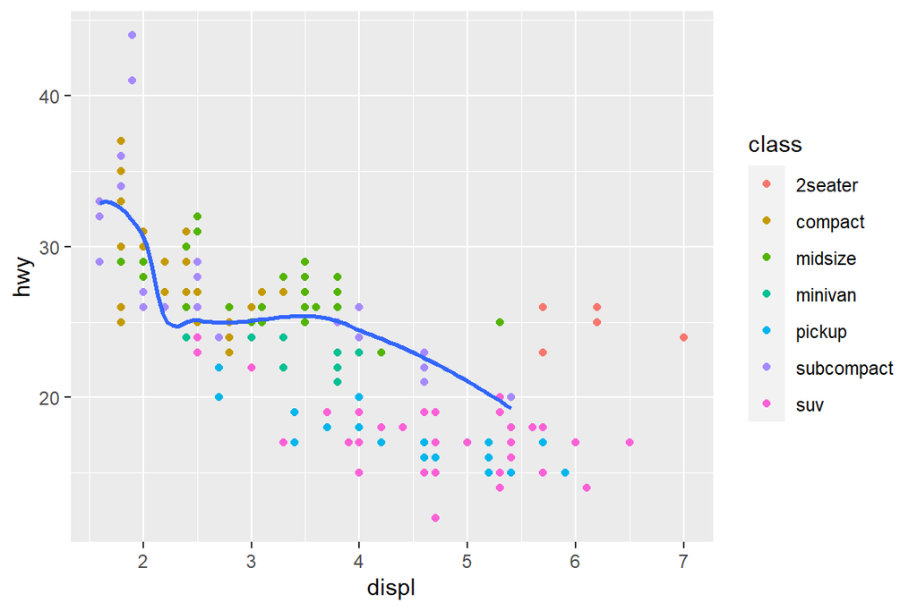

```r
ggplot(data = mpg, mapping = aes(x = displ, y = hwy)) +
  geom_point(mapping = aes(color = class)) +
  geom_smooth(data = filter(mpg, class == "subcompact"), se = FALSE)
```

### Outros exemplos

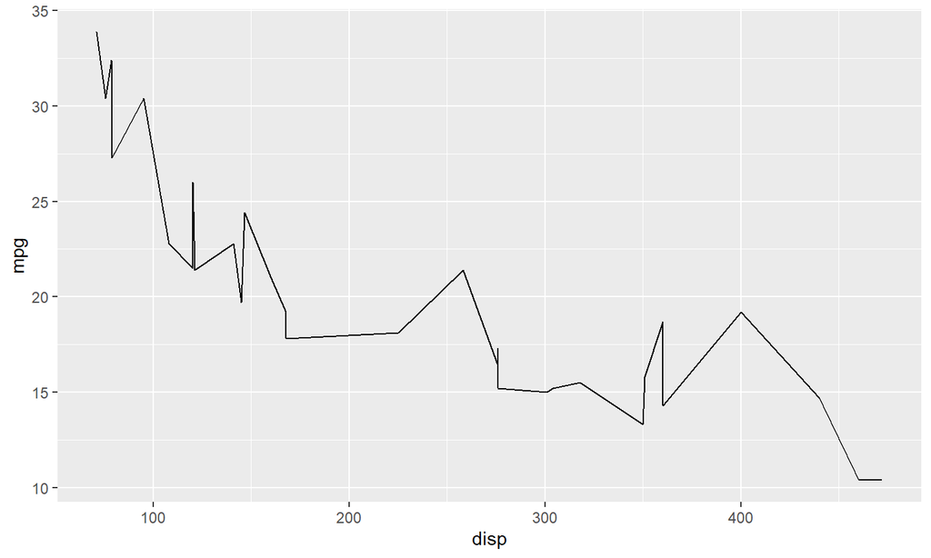

```r
# Grafico de x versus y
ggplot(data = mtcars, aes(x = disp, y = mpg)) +
  geom_line()
```

- geom_abline: para retas definidas por um intercepto e uma inclinação

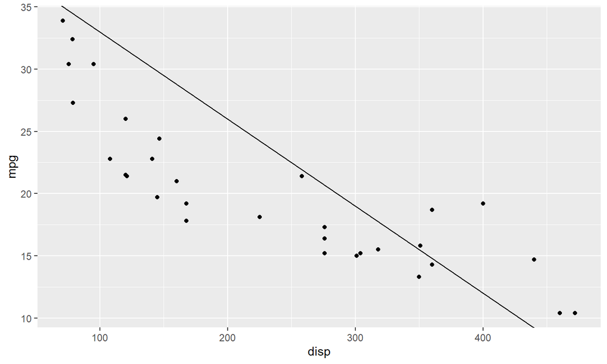

```r
# Grafico de x versus y
ggplot(data = mtcars, aes(x = disp, y = mpg)) +
  geom_point() + geom_abline(intercept = 40, slope = -0.07)
```

- geom_hline: para retas horizontais

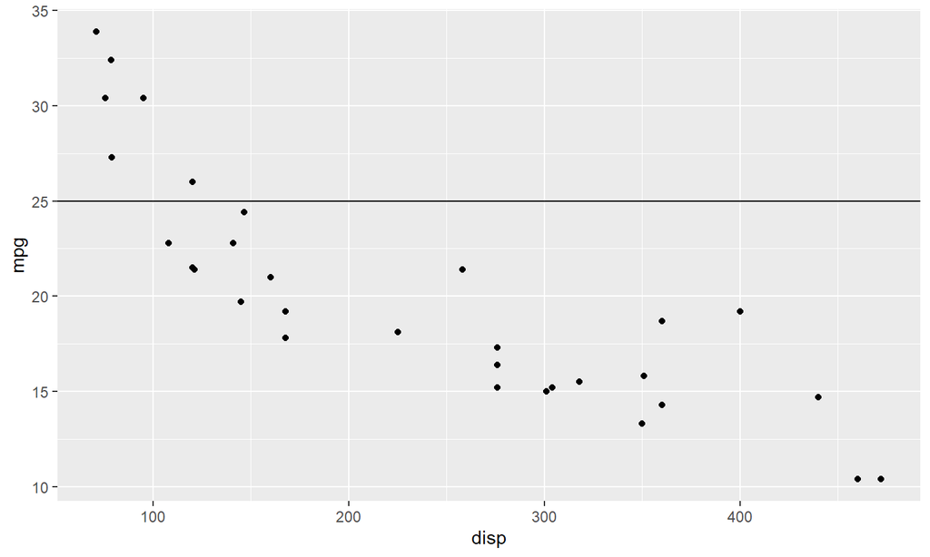

```r
# Grafico de x versus y
ggplot(data = mtcars, aes(x = disp, y = mpg)) +
  geom_point() + geom_hline(yintercept = 25)
```

- geom_boxplot: para boxplots

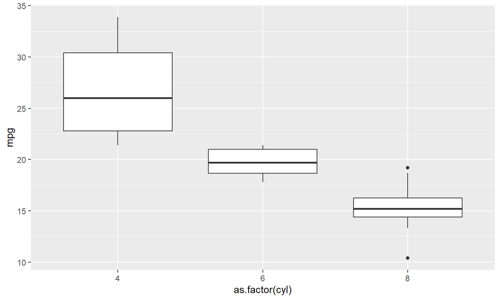

```r
ggplot(mtcars, aes(x = as.factor(cyl), y = mpg)) +
  geom_boxplot()
```

- geom_histogram: para histogramas

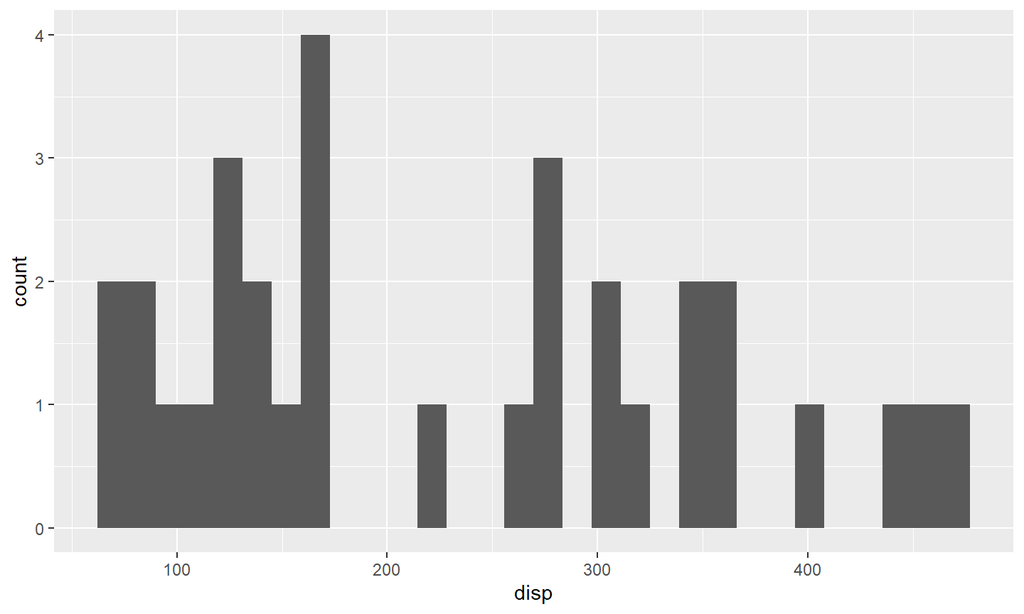

```r
ggplot(data = mtcars, aes(x = disp)) +
  geom_histogram()
```

- geom_density: para densidades

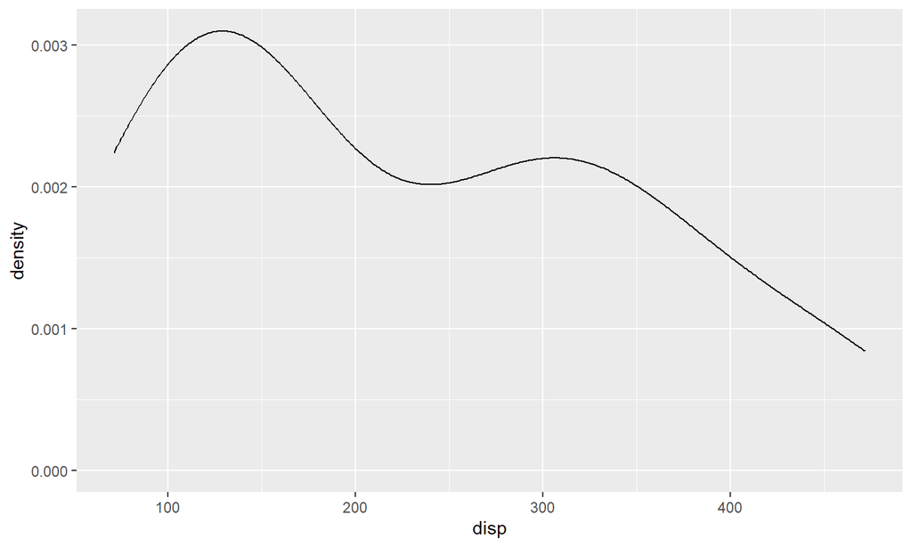

```r
ggplot(data = mtcars, aes(x = disp)) +
  geom_density()
```

- geom_area: para áreas

http://www.sthda.com/english/wiki/ggplot2-area-plot-quick-start-guide-r-software-and-data-visualization

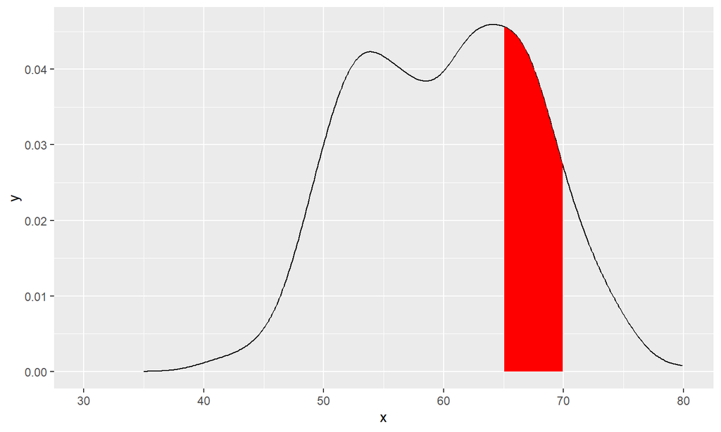

```r
set.seed(1234)
df <- data.frame(
  sex=factor(rep(c("F", "M"), each=200)),
  weight=round(c(rnorm(200, mean=55, sd=5),
                 rnorm(200, mean=65, sd=5)))
  )
dat <- with(density(df$weight), data.frame(x, y))
ggplot(data = dat, mapping = aes(x = x, y = y)) +
    geom_line()+
    geom_area(mapping = aes(x = ifelse(x>65 & x< 70 , x, 0)), fill = "red") +
    xlim(30, 80)
```

## Transformações estatísticas

O gráfico a seguir exibe o número total de diamantes no conjunto de dados diamonds, agrupados por cut.

- O conjunto de dados diamonds vem no ggplot2 e contém informações sobre cerca de 54.000 diamantes, incluindo os price, carat, color, clarity e cut de cada diamante.
- O gráfico mostra que mais diamantes estão disponíveis com cortes de alta qualidade do que com cortes de baixa qualidade.

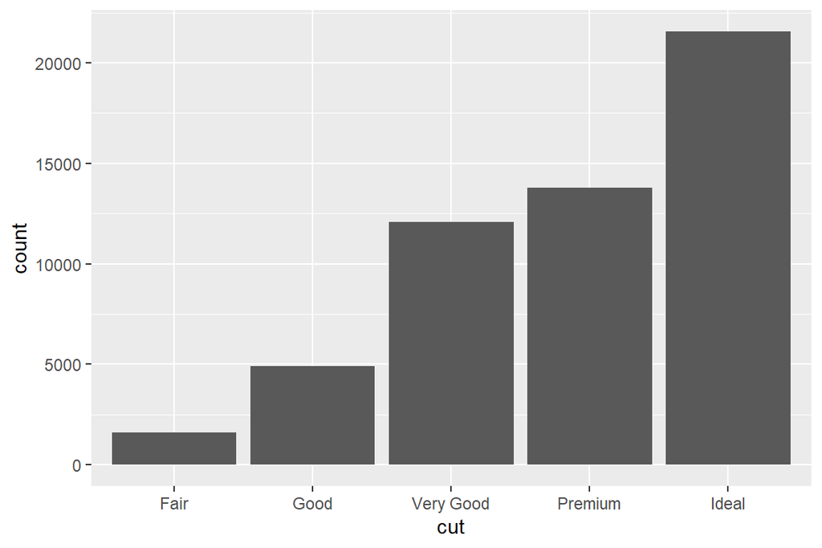

```r
ggplot(data = diamonds) +
  geom_bar(mapping = aes(x = cut))
```

- No eixo x, o gráfico exibe cut, uma variável de diamonds.
- No eixo y, ele exibe contagem, mas contagem não é uma variável em diamonds! De onde vem a contagem?
  - Muitos gráficos, como diagramas de dispersão, traçam os valores brutos do seu conjunto de dados.
  - Outros gráficos, como gráficos de barras, calculam novos valores para plotar:
- gráficos de barras, histogramas e polígonos de frequência agrupam seus dados e, em seguida, plotam as contagens de bin, o número de pontos que caem em cada bin.
- os suavizadores ajustam um modelo aos seus dados e, em seguida, traçam as previsões do modelo.
- boxplots calculam um resumo robusto da distribuição e, em seguida, exibem uma caixa especialmente formatada.

O algoritmo usado para calcular novos valores para um gráfico é chamado de **stat**, abreviação de transformação estatística.